# A Young Man’s Game

Michael Foley

2022-05-26

A major league baseball career can expect to last into the player’s mid-thirties. Advances in sports training might extend careers. Using a data set of every person who has played in a Major League game, this analysis investigates changes in career longevity.

This document is the detailed work log. The final report is published here, and a summarized account is in the repository ReadMe and blog.

# Setup

In addition to the usual packages, include **survival** for modeling, **survminer** for visualization, and **gtsummary** for summaries.

```r
library(tidyverse)
library(janitor)
library(glue)
library(scales)
library(lubridate)
library(extrafont)
library(survival)
library(survminer)
library(gtsummary)

# More mlb colors: https://www.schemecolor.com/tag/mlb
mlb_palette <- c(
  "guardian_blue" = "#0C2340", "guardian_red" = "#E31937",
  "giant_brown" = "#C49D6E", "giant_beige" = "#E8D8C4",
  "giant_orange" = "#F4793E", "giant_black" = "#231F20"
)

theme_set(theme_light())
theme_update(
  text = element_text(
    size = 16,
    family = "TR Plaza",
    color = mlb_palette["giant_black"]
  ),
  panel.grid.minor = element_blank(),
  strip.background = element_rect(
    fill = mlb_palette["giant_beige"],
    color = mlb_palette["giant_brown"]
  ),
  strip.text = element_text(
    color = mlb_palette["giant_black"]
  ),
  plot.caption = element_text(family = "Calibri", size = 11),
  plot.subtitle = element_text(family = "Calibri", size = 12)
)
```

# Data Management

Retrosheet publishes biographical information of every person who has ever played Major League baseball ([codebook and file](https://www.retrosheet.org/biofile.htm)). I downloaded the file to the ../data dir.

```r
# https://www.retrosheet.org/biofile.htm
bio_0 <- readr::read_csv(
  file.path("../data/BIOFILE.TXT"),
  # Initially treat all cols as character; transform later.
  col_types = paste(rep("c", 33), collapse = "")
)

# Last file update is last known observation date. Use in date calcs.
bio_last_updated <- ymd("2021-12-02")
```

The file consists of 21,574 rows and 33 columns, one row per player, manager/coach, and umpire. The column definitions are in the [codebook](https://www.retrosheet.org/biofile.htm). This analysis is limited to players, so filter for non-null `PLAY DEBUT` rows and player related cols. Switch to snake-case too.

```r
bio_1 <- bio_0 %>%
  filter(!is.na(`PLAY DEBUT`)) %>%
  select(-c(`MGR DEBUT`:`UMP LASTGAME`, `NAME CHG`, `BAT CHG`, `BIRTH NAME`)) %>%
  clean_names(case = "snake")
```

That reduces the data set to 20,167 x 24. There are some data irregularities that I discovered in later steps. Fix them here.

```r
bio_2 <- bio_1 %>%
  mutate(
    # Birth dates with unknown day have format MM/ /YYYY, MM /YYYY, or MM/YYYY.
    # Impute mid-month (15th).
    birthdate = str_remove_all(birthdate, " "),
    birthdate = str_replace(birthdate, "\\/\\/", "\\/15\\/"),
    birthdate = if_else(
      str_count(birthdate, "\\/") == 1,
      str_replace(birthdate, "\\/", "\\/15\\/"),
      birthdate
    ),
    # Birth dates with unknown month are in format YYYY. Impute mid-year.
    birthdate = if_else(!str_detect(birthdate, "\\/"),
                        paste0("06/30/", birthdate), birthdate),
    # Same with death dates.
    deathdate = if_else(!str_detect(deathdate, "\\/"),
                        paste0("06/30/", deathdate), deathdate),
    # Dan McGarvey has a typo!
    birthdate = if_else(birthdate == "12/2/2887", "12/2/1887", birthdate),
    # So does Eddie Quick.
    birthdate = if_else(birthdate == "12/1527/1881", "12/15/1881", birthdate),
    # Andrew Carignan was not born in 1868!
    birthdate = if_else(playerid == "caria001", "07/23/1986", birthdate),
    # Melvin Dorta is not dead.
    deathdate = if_else(playerid == "dortm001", NA_character_, deathdate),
    # But Mike Marshall is.
    deathdate = if_else(playerid == "marsm101", "05/31/2021", deathdate),
    # Loaded everything as character. Cast to correct data type now.
    across(contains(c("date", "debut", "lastgame")), mdy),
    weight = as.numeric(weight),
    bats = factor(bats, levels = c("L", "R", "B"),
                  labels = c("Left", "Right", "Both")),
    throws = factor(throws, levels = c("L", "R", "B"),
                    labels = c("Left", "Right", "Both")),
    hof = factor(if_else(is.na(hof), "NOT", hof), levels = c("NOT", "HOF"),
                         labels = c("Out", "In"))
  )
```

Engineer some time length features to support survival models. Three good ways to look at longevity are lifetimes, career lengths, and age at career-end.

```r
# Need to be careful with null (missing) birth dates and death dates. A null
# death date either means unknown or the player hasn't died yet.
bio_3 <- bio_2 %>%
  mutate(
    life_yrs = time_length(
      interval(birthdate, coalesce(deathdate, bio_last_updated)),
      "years"
    ),
    # If age > 110 years, or there is no death date but there is another
    # indicator of death, then you do not know how long they lived.
    life_yrs = if_else(
      life_yrs > 110 |
        (is.na(deathdate) & (
          !is.na(death_city) | !is.na(death_state) | !is.na(death_country) |
            !is.na(cemetery) | !is.na(ceme_city) | !is.na(ceme_state) |
            !is.na(ceme_country) | !is.na(ceme_note))),
      NA_real_,
      life_yrs
    ),
    career_yrs = time_length(
      interval(play_debut, play_lastgame),
      "years"
    ),
    play_lastgame_life_yrs = time_length(
      interval(birthdate, play_lastgame),
      "years"
    ),
    # Event status (1 = event, 0 = censor, NA = don't know)
    life_status = case_when(
      is.na(life_yrs) ~ NA_integer_,  # don't know
      !is.na(deathdate) ~ 1L,  # died
      TRUE ~ 0L  # alive
    ),
    # There is no retirement date. Assume its the last game played for cases
    # where the player has been out of the game for over 2 years.
    yrs_since_lastgame = time_length(
      interval(play_lastgame, bio_last_updated),
      "years"
    ),
    career_status = case_when(
      is.na(career_yrs) ~ NA_integer_,  # don't know
      yrs_since_lastgame > 2 ~ 1L,  # no longer playing
      TRUE ~ 0L # still playing
    )
  ) %>%
  select(-c(starts_with("death_"), starts_with("ceme"), yrs_since_lastgame))
```

One more data change. `height` is in format FT-IN. Parse it to calculate the height in inches.

```r
bio_4 <- bio_3 %>%
  mutate(
    tmp_height = map(height, ~str_split(.x, "-", n = 2) %>% pluck(1)),
    tmp_height_ft = map_dbl(
      tmp_height,
      ~if_else(is.null(.x), "", pluck(.x, 1)) %>% as.numeric()
    ),
    tmp_height_in = map_dbl(
      tmp_height,
      ~if_else(is.null(.x), "", pluck(.x, 2)) %>% as.numeric()
    ),
    tmp_height_ft_2 = if_else(tmp_height_ft <= 7, tmp_height_ft, NA_real_),
    height_in = tmp_height_ft_2 * 12 + tmp_height_in
  ) %>%
  select(-c(starts_with("tmp_"), height))
```

Anything else interesting? Maybe body-mass index from the height and weight.

```r
bio_5 <- bio_4 %>% mutate(bmi = weight / height_in^2 * 703)
```

Final look at the data.

```r
bio <- bio_5
skimr::skim(bio)
```

Data summary

| Name | bio |
| --- | --- |
| Number of rows | 20167 |
| Number of columns | 22 |
| _______________________ |  |
| Column type frequency: |  |
| character | 7 |
| Date | 4 |
| factor | 3 |
| numeric | 8 |
| ________________________ |  |
| Group variables | None |

**Variable type: character**

| skim_variable | n_missing | complete_rate | min | max | empty | n_unique | whitespace |
| --- | --- | --- | --- | --- | --- | --- | --- |
| playerid | 0 | 1.00 | 8 | 8 | 0 | 20167 | 0 |
| last | 0 | 1.00 | 2 | 18 | 0 | 10244 | 0 |
| first | 36 | 1.00 | 2 | 43 | 0 | 13830 | 0 |
| nickname | 36 | 1.00 | 2 | 13 | 0 | 2556 | 0 |
| birth_city | 148 | 0.99 | 3 | 34 | 0 | 4948 | 0 |
| birth_state | 811 | 0.96 | 3 | 22 | 0 | 211 | 0 |
| birth_country | 58 | 1.00 | 3 | 18 | 0 | 62 | 0 |

**Variable type: Date**

| skim_variable | n_missing | complete_rate | min | max | median | n_unique |
| --- | --- | --- | --- | --- | --- | --- |
| birthdate | 114 | 0.99 | 1832-09-17 | 2001-03-01 | 1943-08-23 | 16289 |
| play_debut | 0 | 1.00 | 1871-05-04 | 2021-10-03 | 1966-04-23 | 10711 |
| play_lastgame | 0 | 1.00 | 1871-05-05 | 2021-11-02 | 1972-06-21 | 9905 |
| deathdate | 10403 | 0.48 | 1872-03-17 | 2021-11-15 | 1969-03-17 | 8745 |

**Variable type: factor**

| skim_variable | n_missing | complete_rate | ordered | n_unique | top_counts |
| --- | --- | --- | --- | --- | --- |
| bats | 1075 | 0.95 | FALSE | 3 | Rig: 12553, Lef: 5305, Bot: 1234 |
| throws | 870 | 0.96 | FALSE | 3 | Rig: 15401, Lef: 3892, Bot: 4 |
| hof | 0 | 1.00 | FALSE | 2 | Out: 19906, In: 261 |

**Variable type: numeric**

| skim_variable | n_missing | complete_rate | mean | sd | p0 | p25 | p50 | p75 | p100 | hist |
| --- | --- | --- | --- | --- | --- | --- | --- | --- | --- | --- |
| weight | 727 | 0.96 | 185.88 | 20.67 | 65.00 | 170.00 | 185.00 | 200.00 | 320.00 | ▁▂▇▁▁ |
| life_yrs | 167 | 0.99 | 59.06 | 19.11 | 19.54 | 42.96 | 60.28 | 74.71 | 107.36 | ▅▆▇▇▁ |
| career_yrs | 0 | 1.00 | 4.85 | 4.98 | 0.00 | 0.42 | 3.25 | 8.02 | 35.22 | ▇▃▁▁▁ |
| play_lastgame_life_yrs | 114 | 0.99 | 29.24 | 4.82 | 16.49 | 25.77 | 28.60 | 32.39 | 59.22 | ▂▇▂▁▁ |
| life_status | 167 | 0.99 | 0.49 | 0.50 | 0.00 | 0.00 | 0.00 | 1.00 | 1.00 | ▇▁▁▁▇ |
| career_status | 0 | 1.00 | 0.91 | 0.28 | 0.00 | 1.00 | 1.00 | 1.00 | 1.00 | ▁▁▁▁▇ |
| height_in | 654 | 0.97 | 72.42 | 2.58 | 43.00 | 71.00 | 72.00 | 74.00 | 83.00 | ▁▁▁▇▁ |
| bmi | 785 | 0.96 | 24.87 | 1.98 | 17.72 | 23.67 | 24.67 | 25.85 | 40.29 | ▁▇▂▁▁ |

```r
rm(bio_0, bio_1, bio_2, bio_3, bio_4, bio_5)
```

# Exploration

This section is primarily univariate analyses to get a feel for the data and to establish expectations for the survival models.

## Height and Weight

```r
bio %>%
  mutate(birthyear = year(birthdate)) %>%
  filter(birthyear %in% c(1850, 1896, 1996)) %>%
  gtsummary::tbl_summary(
    by = birthyear,
    statistic = list(all_continuous() ~ "{mean}, {median} ({p25}, {p75})"),
    digits = list(height_in ~ 0, weight ~ 0, bmi ~ 1),
    include = c("height_in", "weight", "bmi")
  ) %>% modify_caption("Table 1. MLB pLayer size for select birth years.")
```

Table 1. MLB pLayer size for select birth years.

| **Characteristic** | **1850**, N = 43<sup>1</sup> | **1896**, N = 133<sup>1</sup> | **1996**, N = 168<sup>1</sup> |
| --- | --- | --- | --- |
| height_in | 69, 68 (67, 71) | 71, 71 (70, 72) | 74, 74 (72, 75) |
| Unknown | 14 | 1 | 0 |
| weight | 164, 164 (150, 180) | 172, 172 (162, 180) | 204, 205 (186, 218) |
| Unknown | 14 | 3 | 0 |
| bmi | 24.2, 24.0 (22.4, 26.0) | 24.1, 24.1 (23.1, 25.0) | 26.3, 26.5 (24.4, 27.7) |
| Unknown | 14 | 3 | 0 |

<sup>*1*</sup> Mean, Median (IQR)

### Taller

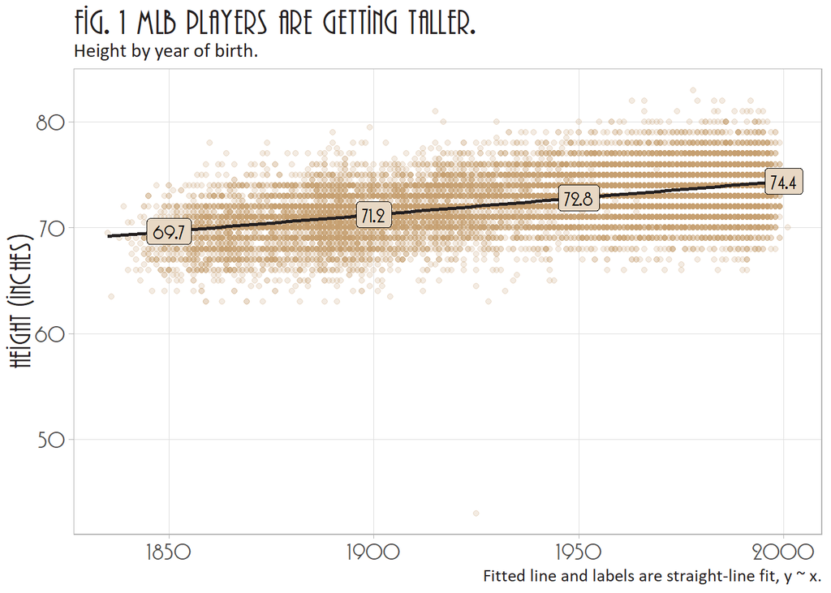

```r
dat <- bio %>%
  filter(!is.na(birthdate) & !is.na(height_in)) %>%
  mutate(yr = lubridate::year(birthdate))

label_yrs <- c(1850, 1900, 1950, 2000)

mdl_preds <- dat %>% lm(height_in ~ yr, data = .) %>%
  predict(newdata = list(yr = label_yrs))
label_dat <- data.frame(yr = label_yrs, height_in = mdl_preds)

p1 <- dat %>%
  ggplot(aes(x = yr, y = height_in)) +
  geom_point(alpha = .2, color = mlb_palette["giant_brown"]) +
  geom_smooth(method = "lm", formula = "y~x", color = mlb_palette["giant_black"]) +
  geom_label(
    data = label_dat,
    aes(label = comma(height_in, .1)),
    family = "TR Plaza",
    fill = mlb_palette["giant_beige"]
  ) +
  labs(
    title = "MLB Players Are Getting Taller.",
    subtitle = "Height by year of birth.",
    caption = "Fitted line and labels are straight-line fit, y ~ x.",
    y = "height (inches)", x = NULL
  )
p1 + ggtitle(paste("Fig. 1", p1$labels$title))
```

### Heavier

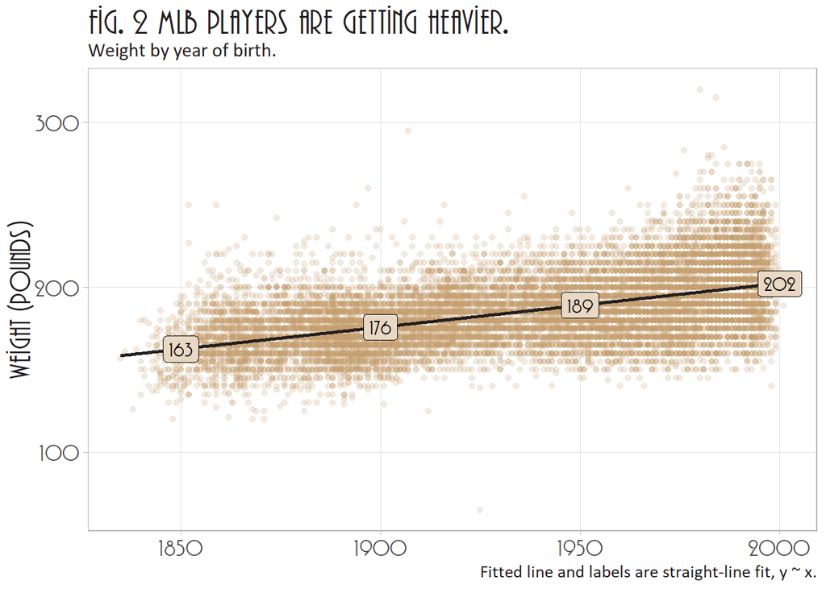

```r
dat <- bio %>%
  filter(!is.na(birthdate) & !is.na(weight)) %>%
  mutate(yr = lubridate::year(birthdate))

label_yrs <- c(1850, 1900, 1950, 2000)

mdl_preds <- dat %>% lm(weight ~ yr, data = .) %>%
  predict(newdata = list(yr = label_yrs))
label_dat <- data.frame(yr = label_yrs, weight = mdl_preds)

p2 <- dat %>%
  ggplot(aes(x = yr, y = weight)) +
  geom_point(alpha = .2, color = mlb_palette["giant_brown"]) +
  geom_smooth(method = "lm", formula = "y~x", color = mlb_palette["giant_black"]) +
  geom_label(
    data = label_dat,
    aes(label = comma(weight, 1)),
    family = "TR Plaza",
    fill = mlb_palette["giant_beige"]
  ) +
  labs(
    title = "MLB Players Are Getting Heavier.",
    subtitle = "Weight by year of birth.",
    caption = "Fitted line and labels are straight-line fit, y ~ x.",
    y = "weight (pounds)", x = NULL
  )
p2 + ggtitle(paste("Fig. 2", p2$labels$title))
```

### and More Massive

Height and weight can be combined into a single measure of mass, the BMI.

$$BMI = \frac{weight}{height^2} \times 703$$

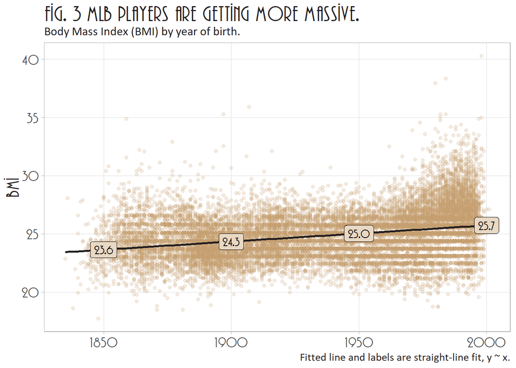

```r
dat <- bio %>%
  filter(!is.na(birthdate) & !is.na(bmi)) %>%
  mutate(yr = lubridate::year(birthdate))

label_yrs <- c(1850, 1900, 1950, 2000)

mdl_preds <- dat %>% lm(bmi ~ yr, data = .) %>%
  predict(newdata = list(yr = label_yrs))
label_dat <- data.frame(yr = label_yrs, bmi = mdl_preds)

p3 <- dat %>%
  ggplot(aes(x = yr, y = bmi)) +
  geom_point(alpha = .2, color = mlb_palette["giant_brown"]) +
  geom_smooth(method = "lm", formula = "y~x", color = mlb_palette["giant_black"]) +
  geom_label(
    data = label_dat,
    aes(label = comma(bmi, .1)),
    family = "TR Plaza",
    fill = mlb_palette["giant_beige"]
  ) +
  labs(
    title = "MLB Players Are Getting More Massive.",
    subtitle = "Body Mass Index (BMI) by year of birth.",
    caption = "Fitted line and labels are straight-line fit, y ~ x.",
    y = "bmi", x = NULL
  )
p3 + ggtitle(paste("Fig. 3", p3$labels$title))
```

```r
bio %>%
  filter(life_status == 1) %>%
  mutate(birth_year = year(birthdate)) %>%
  lm(life_yrs ~ height_in + birth_year, data = .) %>%
  gtsummary::tbl_regression()
```

| **Characteristic** | **Beta** | **95% CI**<sup>1</sup> | **p-value** |
| --- | --- | --- | --- |
| height_in | -0.17 | -0.32, -0.02 | 0.025 |
| birth_year | 0.06 | 0.05, 0.07 | <0.001 |

<sup>*1*</sup> CI = Confidence Interval

## Handedness

Batting left-handed may be due to strategy rather than handedness. Throwing is almost certainly an indicator of handedness. Evidence of this is in the number of ambidextrous pitchers - there are almost none. The Psychology Today blog suggests cultural norms play a role in handedness. Fig 4 shows an increasing trend in the proportion of left-handed pitchers up until 1950.

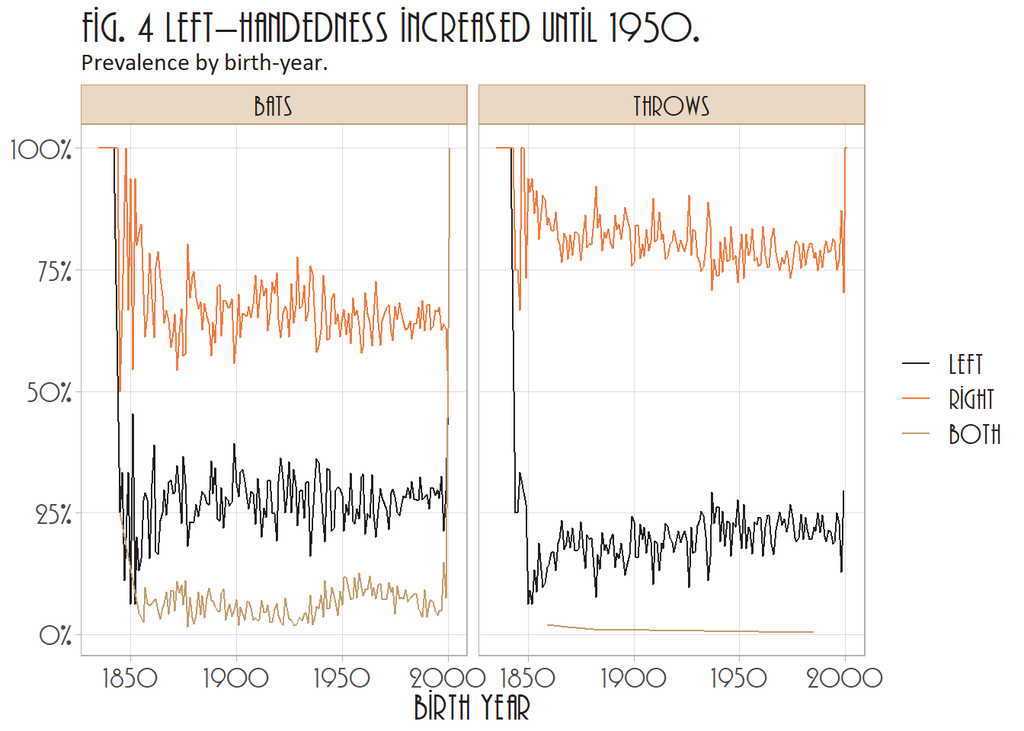

```r
p4 <- bio %>%
  # About 5% of rows are missing a value for either `bats` or `throws`.
  filter(!is.na(bats) & !is.na(throws)) %>%
  filter(!is.na(birthdate)) %>%
  mutate(birth_year = year(birthdate)) %>%
  pivot_longer(cols = c(bats, throws)) %>%
  group_by(birth_year, name, value) %>%
  summarize(.groups = "drop_last", n = n()) %>%
  mutate(pct = n / sum(n)) %>%
  ungroup() %>%
  ggplot(aes(x = birth_year, y = pct, color = value)) +
  geom_line() +
  scale_y_continuous(labels = percent_format(1)) +
  scale_color_manual(values = as.character(mlb_palette[c(6, 5, 3)])) +
  facet_wrap(facets = vars(name)) +
  labs(
    x = "Birth Year", y = NULL, color = NULL,
    title = "Left-handedness increased until 1950.",
    subtitle = "Prevalence by birth-year."
  )
p4 + ggtitle(paste("Fig. 4", p4$labels$title))
```

## Birthplace

MLB has a relatively high concentration of ballplayers of Latin descent. Many were born outside the US. Of ballplayers born in the US, most are naturally from high population states. Adding population data to the data set will normalize the player counts for comparison.

```r
# Help from https://r-spatial.org/r/2018/10/25/ggplot2-sf.html.

library(sf)
library(rnaturalearth)
library(rnaturalearthdata)
library(ggspatial)

# Geo data.
world_dat <- ne_countries(scale = "medium", returnclass = "sf")
state_dat <- ne_states(country = "United States of America", returnclass = "sf")

# Make X, Y coordinates for country and state labels.
world_centroid <- world_dat %>%
  st_make_valid() %>%
  st_centroid() %>%
  st_coordinates()
state_centroid <- state_dat %>%
  st_make_valid() %>%
  st_centroid() %>%
  st_coordinates()

# Modify country names in bio to match those in world_dat.
bio_country <- bio %>%
  mutate(
    birth_country = case_when(
      birth_country == "Dominican Republic" ~ "Dominican Rep.",
      birth_country == "Curacao" ~ "Curaçao",
      birth_country == "England" ~ "United Kingdom",
      birth_country == "Canal Zone" ~ "Panama",
      birth_country == "USA" ~ "United States",
      birth_country == "South Korea" ~ "Korea",
      birth_country == "South Vietnam" ~ "Vietnam",
      birth_country == "Virgin Islands" ~ "U.S. Virgin Is.",
      birth_country == "West Germany" ~ "Germany",
      birth_country == "Austria-Hungary" ~ "Austria",
      birth_country == "British Honduras" ~ "Honduras",
      birth_country == "Czechoslovakia" ~ "Czech Rep.",
      birth_country == "Northern Ireland" ~ "Ireland",
      birth_country == "Dominican Republic" ~ "Dominican Rep.",
      TRUE ~ birth_country
    )
  )

# Current players per capita
bio_country_n <- bio_country %>%
  filter(career_status == 0) %>%
  count(birth_country) %>%
  left_join(world_dat %>% select(name, pop_est),
            by = c("birth_country" = "name")) %>%
  mutate(n_per_capita = n / pop_est)

census_pop <- readr::read_csv(
  "https://www2.census.gov/programs-surveys/popest/datasets/2020-2021/state/totals/NST-EST2021-alldata.csv"
)

bio_state_n <- bio %>%
  filter(career_status == 0 & birth_country == "USA") %>%
  count(birth_state) %>%
  inner_join(census_pop, by = c("birth_state" = "NAME")) %>%
  mutate(n_per_capita = n / POPESTIMATE2021)
```

### International

28% of today’s MLB players were born outside the US. The Dominican Republic is the largest source of talent (194 players), and has a stunning per capita contribution of 20.1 players per million of population. The tiny island of Curaçao, population 142,000, boasts 6 players for a whopping per capita contribution of 42.3 players per million.

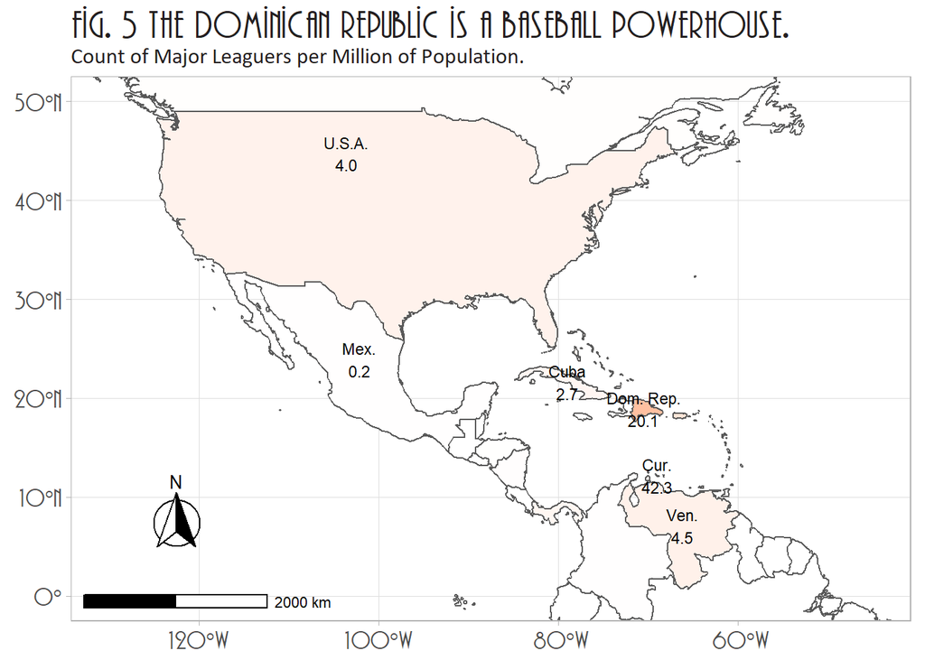

```r
p5 <- world_dat %>%
  cbind(world_centroid) %>%
  left_join(bio_country_n, by = c("name" = "birth_country")) %>%
  replace_na(list(n_per_capita = 0)) %>%
  mutate(
    lbl = if_else(name %in% c("United States", "Mexico", "Dominican Rep.", "Cuba", "Venezuela", "Curaçao"),
                  glue("{abbrev}\n{comma(n_per_capita * 1E6, .1)}"),
                  glue(""))
  ) %>%
  ggplot() +
  geom_sf(aes(fill = n_per_capita), show.legend = FALSE) +
  geom_text(aes(x = X, y = Y, label = lbl),
    color = "black",
    # fontface = "bold",
    check_overlap = FALSE,
    # family = "TR Plaza",
    size = 3.0
  ) +
  scale_fill_gradient(low = "white", high = mlb_palette["giant_orange"]) +
  annotation_scale(location = "bl", width_hint = 0.25) +
  annotation_north_arrow(location = "bl", which_north = "true",
                         pad_x = unit(0.5, "in"), pad_y = unit(0.5, "in"),
                         style = north_arrow_fancy_orienteering) +
  coord_sf(xlim = c(-130, -45), ylim = c(0, 50)) +
  labs(
    title = "The Dominican Republic is a baseball powerhouse.",
    subtitle = "Count of Major Leaguers per Million of Population.",
    x = NULL, y = NULL, fill = NULL
  )

p5 + ggtitle(paste("Fig. 5", p5$labels$title))
```

### Domestic

California (262) and Florida (135) are not only the highest overall producers of talent, they are also the highest per-capita producers (along with Georgia).

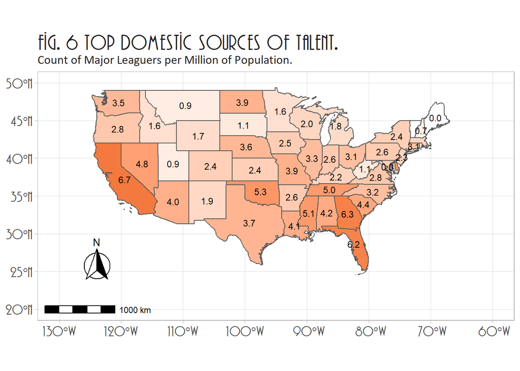

```r
p6 <- state_dat %>%
  cbind(state_centroid) %>%
  left_join(bio_state_n, by = c("name" = "birth_state")) %>%
  replace_na(list(n_per_capita = 0)) %>%
  mutate(lbl = comma(n_per_capita * 1E6, .1)) %>%
  ggplot() +
  geom_sf(aes(fill = n_per_capita), show.legend = FALSE) +
  geom_text(aes(x = X, y = Y, label = lbl),
    color = "black",
    # fontface = "bold",
    check_overlap = TRUE,
    # family = "TR Plaza",
    size = 3.0
  ) +
  scale_fill_gradient(low = "white", high = mlb_palette["giant_orange"]) +
  annotation_scale(location = "bl", width_hint = 0.25) +
  annotation_north_arrow(location = "bl", which_north = "true",
                         pad_x = unit(0.5, "in"), pad_y = unit(0.5, "in"),
                         style = north_arrow_fancy_orienteering) +
  coord_sf(xlim = c(-130, -60), ylim = c(20, 50)) +
  labs(
    title = "Top Domestic Sources of Talent.",
    subtitle = "Count of Major Leaguers per Million of Population.",
    x = NULL, y = NULL, fill = NULL
  )
p6 + ggtitle(paste("Fig. 6", p6$labels$title))
```

Major League baseball was not an international organization until after WWII (Fig 7). The earliest ballplayers were often born in Europe.

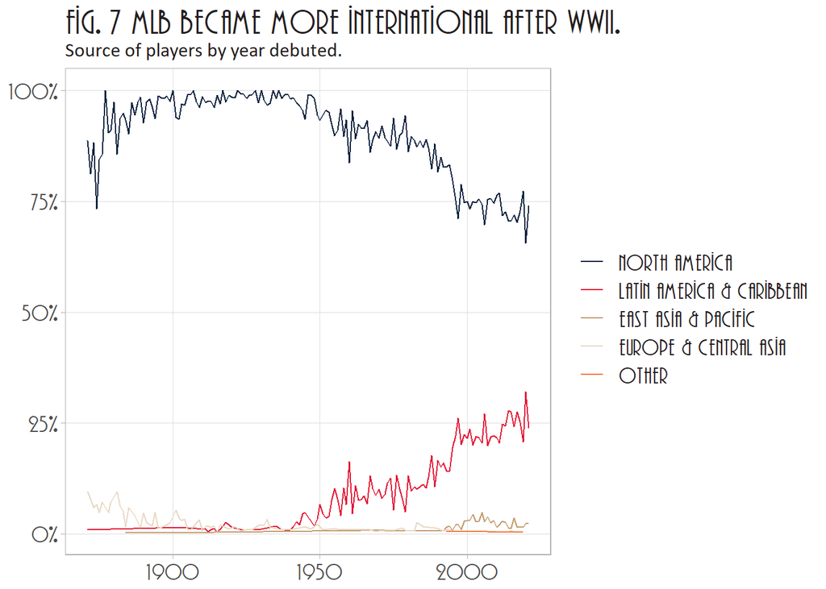

```r
p7 <- bio_country %>%
  left_join(world_dat, by = c("birth_country" = "name")) %>%
  mutate(debut_year = year(play_debut)) %>%
  count(debut_year, region_wb) %>%
  group_by(debut_year) %>%
  mutate(pct = n / sum(n)) %>%
  ungroup() %>%
  filter(!is.na(region_wb)) %>%
  mutate(
    region_wb = fct_relevel(
      region_wb,
      "North America", "Latin America & Caribbean", "East Asia & Pacific"
    ),
    region_wb = fct_collapse(
      region_wb,
      `North America` = "North America",
      `Latin America & Caribbean` = "Latin America & Caribbean",
      `East Asia & Pacific` = "East Asia & Pacific",
      `Europe & Central Asia` = "Europe & Central Asia",
      other_level = "Other"
    )
  ) %>%
  ggplot(aes(x = debut_year)) +
  geom_line(aes(y = pct, color = region_wb)) +
  labs(
    title = "MLB became more international after WWII.",
    subtitle = "Source of players by year debuted.",
    x = NULL, y = NULL, color = NULL
  ) +
  scale_y_continuous(labels = percent_format(1)) +
  scale_color_manual(values = as.character(mlb_palette))

p7 + ggtitle(paste("Fig. 7", p7$labels$title))
```

```r
rm()
```

## Hall of Famers

Switch-hitters are more likely to join the Hall. Next best is batting left.

```r
bio %>%
  # Inactive
  filter(career_status == 1) %>%
  tbl_cross(row = bats, col = hof, percent = "row") %>%
  add_p()
```

| **Characteristic** | **hof** Out | **hof** In | **Total** | **p-value**<sup>1</sup> |  |  |
| --- | --- | --- | --- | --- | --- | --- |
| bats |  |  |  |  |  | <0.001 |
| Left | 4,736 (98%) | 80 (1.7%) | 4,816 (100%) |  |  |  |
| Right | 11,257 (99%) | 159 (1.4%) | 11,416 (100%) |  |  |  |
| Both | 1,116 (98%) | 22 (1.9%) | 1,138 (100%) |  |  |  |
| Unknown | 1,075 (100%) | 0 (0%) | 1,075 (100%) |  |  |  |
| Total | 18,184 (99%) | 261 (1.4%) | 18,445 (100%) |  |  |  |

<sup>*1*</sup> Pearson's Chi-squared test

But its better to throw right.

```r
bio %>%
  # Inactive
  filter(career_status == 1) %>%
  tbl_cross(row = throws, col = hof, percent = "row") %>%
  add_p()
```

| **Characteristic** | **hof** Out | **hof** In | **Total** | **p-value**<sup>1</sup> |  |  |
| --- | --- | --- | --- | --- | --- | --- |
| throws |  |  |  |  |  | <0.001 |
| Left | 3,499 (99%) | 43 (1.2%) | 3,542 (100%) |  |  |  |
| Right | 13,812 (98%) | 218 (1.6%) | 14,030 (100%) |  |  |  |
| Both | 3 (100%) | 0 (0%) | 3 (100%) |  |  |  |
| Unknown | 870 (100%) | 0 (0%) | 870 (100%) |  |  |  |
| Total | 18,184 (99%) | 261 (1.4%) | 18,445 (100%) |  |  |  |

<sup>*1*</sup> Fisher's exact test

Is fame related to longevity? Holy whammer - yes, by five years!

```r
bio %>%
  # deceased
  filter(life_status == 1) %>%
  tbl_summary(by = hof, include = c(life_yrs)) %>%
  add_p()
```

| **Characteristic** | **Out**, N = 9,559<sup>1</sup> | **In**, N = 197<sup>1</sup> | **p-value**<sup>2</sup> |
| --- | --- | --- | --- |
| life_yrs | 71 (59, 81) | 76 (63, 84) | <0.001 |

<sup>*1*</sup> Median (IQR) <sup>*2*</sup> Wilcoxon rank sum test

## Survival

This section explores the relationship between survival (career length, lifetimes, age at career end) and the player attributes in the data set.

```r
plot_km <- function(mdl) {
  mdl %>%
    ggsurvplot(
      data = bio,
      fun = "pct",
      linetype = "strata", # Change line type by groups
      conf.int = TRUE,
      risk.table = TRUE,
      fontsize = 3, # used in risk table
      surv.median.line = "hv", # median horizontal and vertical ref lines
      # ggtheme = theme_light(),
      palette = as.character(mlb_palette[c(6, 5)]),
      subtitle = "Career Length by Hall of Fame Status"
    )
}
```

### Hall of Fame

```r
(km_hof_1 <- survfit(Surv(career_yrs, career_status) ~ hof, data = bio))
```

```
## Call: survfit(formula = Surv(career_yrs, career_status) ~ hof, data = bio)
##
##             n events median 0.95LCL 0.95UCL
## hof=Out 19906  18184    3.8    3.59    3.95
## hof=In    261    261   17.2   16.91   18.03
```

The median career length is 3.8 years for non-Hall of Famers, 17.2 years for those in the Hall.

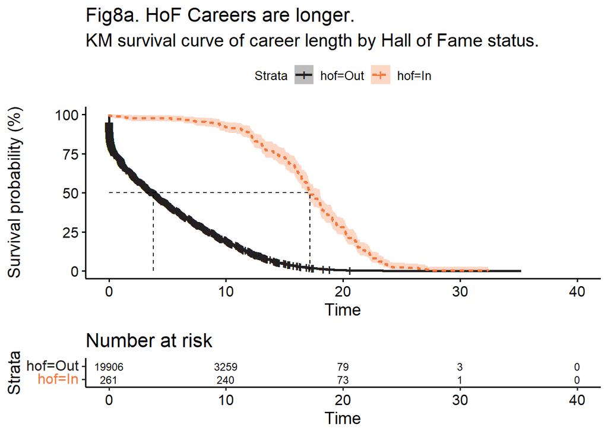

```r
p8a <- km_hof_1 %>% plot_km()

p8a$plot <- p8a$plot +
  labs(
    title = "HoF Careers are longer.",
    subtitle = "KM survival curve of career length by Hall of Fame status."
  )

tmp <- p8a
tmp$plot <- tmp$plot + labs(title = paste("Fig8a.", tmp$plot$labels$title))
tmp
```

```r
(km_hof_2 <- survfit(Surv(play_lastgame_life_yrs, career_status) ~ hof, data = bio))
```

```
## Call: survfit(formula = Surv(play_lastgame_life_yrs, career_status) ~
##     hof, data = bio)
##
##    114 observations deleted due to missingness
##             n events median 0.95LCL 0.95UCL
## hof=Out 19792  18070   28.9    28.8    29.0
## hof=In    261    261   39.0    38.4    39.7
```

The median retirement age is 28.9 years for non-Hall of Famers, 39.0 years for those in the Hall.

```r
(km_hof_3 <- survfit(Surv(life_yrs, life_status) ~ hof, data = bio))
```

```
## Call: survfit(formula = Surv(life_yrs, life_status) ~ hof, data = bio)
##
##    167 observations deleted due to missingness
##             n events median 0.95LCL 0.95UCL
## hof=Out 19739   9559   75.8    75.4    76.1
## hof=In    261    197   79.3    76.4    81.5
```

The median life expectancy is 75.8 years for non-Hall of Famers, 79.3 years for those in the Hall.

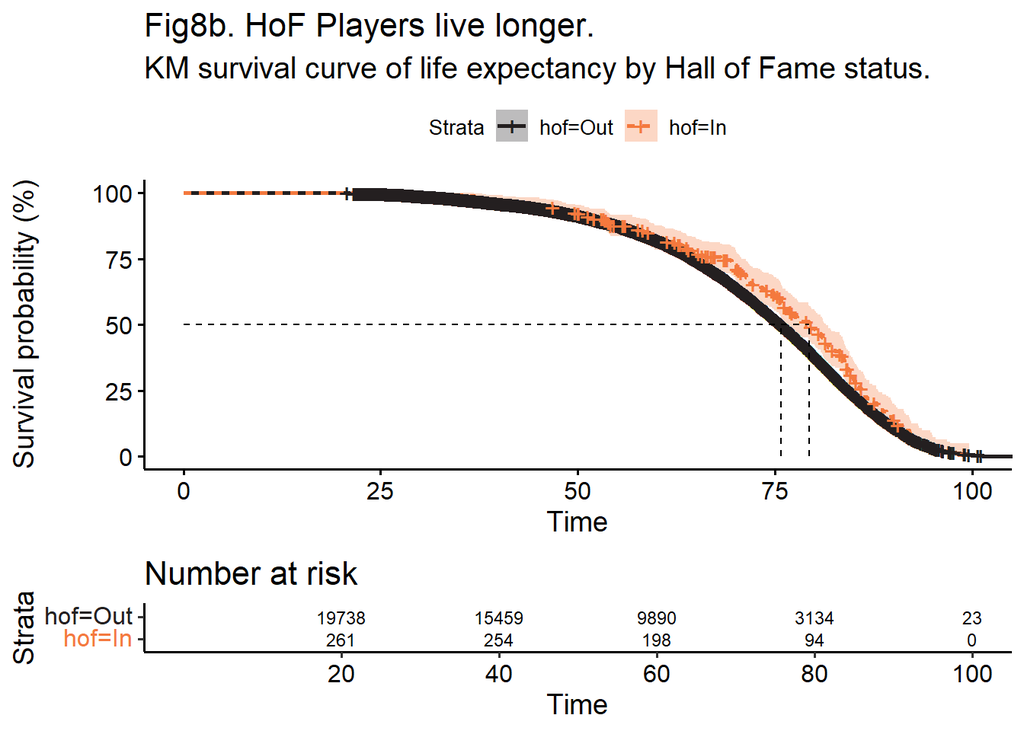

```r
p8b <- km_hof_3 %>% plot_km()

p8b$plot <- p8b$plot +
  labs(
    title = "HoF Players live longer.",
    subtitle = "KM survival curve of life expectancy by Hall of Fame status."
  )

tmp <- p8b
tmp$plot <- tmp$plot + labs(title = paste("Fig8b.", tmp$plot$labels$title))
tmp
```

# Analysis

# Reference

- [Baseball Data Science](https://www.baseballdatascience.com/survival-analysis-how-long-do-careers-last/)
- [NIH](https://www.ncbi.nlm.nih.gov/pmc/articles/PMC2394262/)
- [Dictionary of Old Time Baseball Slang](https://playmakerjournal.net/blogs/news/dictionary-of-old-time-baseball-slang), Playmaker Journal.
- My Supservised ML Notes on [Survival Analysis](https://bookdown.org/mpfoley1973/supervised-ml/survival-analysis.html).